# Tugas Pertemuan 6 dan 7

Azizah

2023-09-26

# Packages

```r
library(ggplot2)
library(tsibble)
library(tseries)
library(MASS)
library(forecast)
library(TSA)
library(TTR)
library(aTSA)
library(graphics)
library(rio)
```

# Input Data

Data yang digunakan adalah data harga daging sapi dari bulan Desember 2020 hingga Agustus 2023 dengan periode per minggu. Data yang digunakan berjumlah 140 data.

```r
datam1<-import("https://raw.githubusercontent.com/azizahaa/MPDW-Prak/main/P1/Data%20Harga%20Daging%20Sapi.csv")
datam6.ts<-ts(datam1[,2])
```

# Eksplorasi Data

## Plot Data Penuh

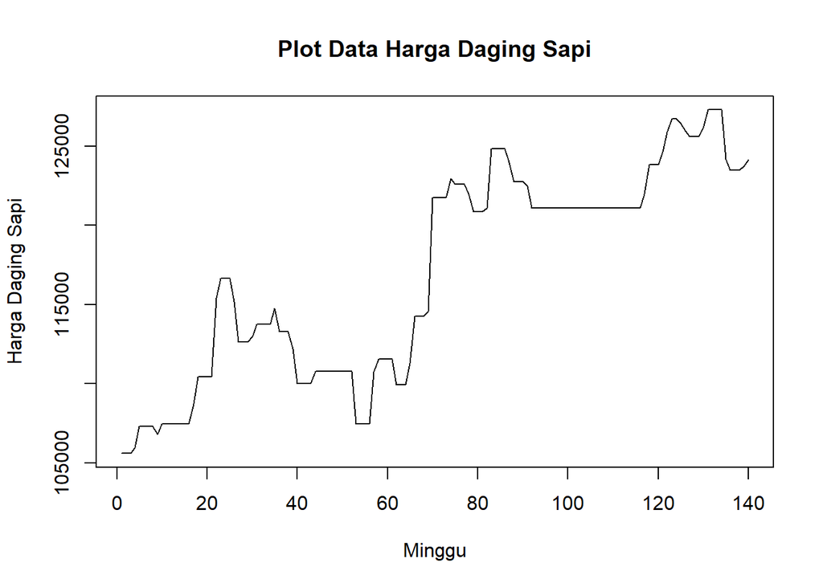

```r
plot.ts(datam6.ts, lty=1, xlab="Minggu", ylab="Harga Daging Sapi", main="Plot Data Harga Daging Sapi")
```

Berdasarkan plot data deret waktu, terlihat bahwa data cenderung mengalami kenaikan (trend naik). Berdasarkan pola data, pembagian data latih dan data uji ditetapkan dengan proporsi 86%:14%.

### Plot Data Latih

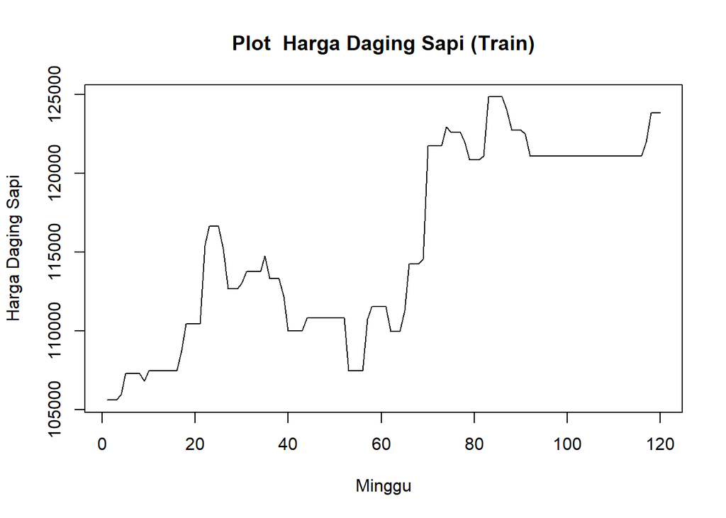

```r
b<-round(140*0.14)
c<-(length(datam6.ts)-b)
datam6.train<-datam6.ts[1:c]
train.ts<-ts(datam6.train)
plot.ts(train.ts, lty=1, xlab="Minggu", ylab="Harga Daging Sapi", main="Plot  Harga Daging Sapi (Train)")
```

Berdasarkan plot data deret waktu pada data latih, terlihat bahwa data cenderung bergerak naik dan cenderung tidak bergerak pada nilai tengah tertentu. Hal ini mengindikasikan bahwa data tidak stasioner dalam rataan.

### Plot Data Uji

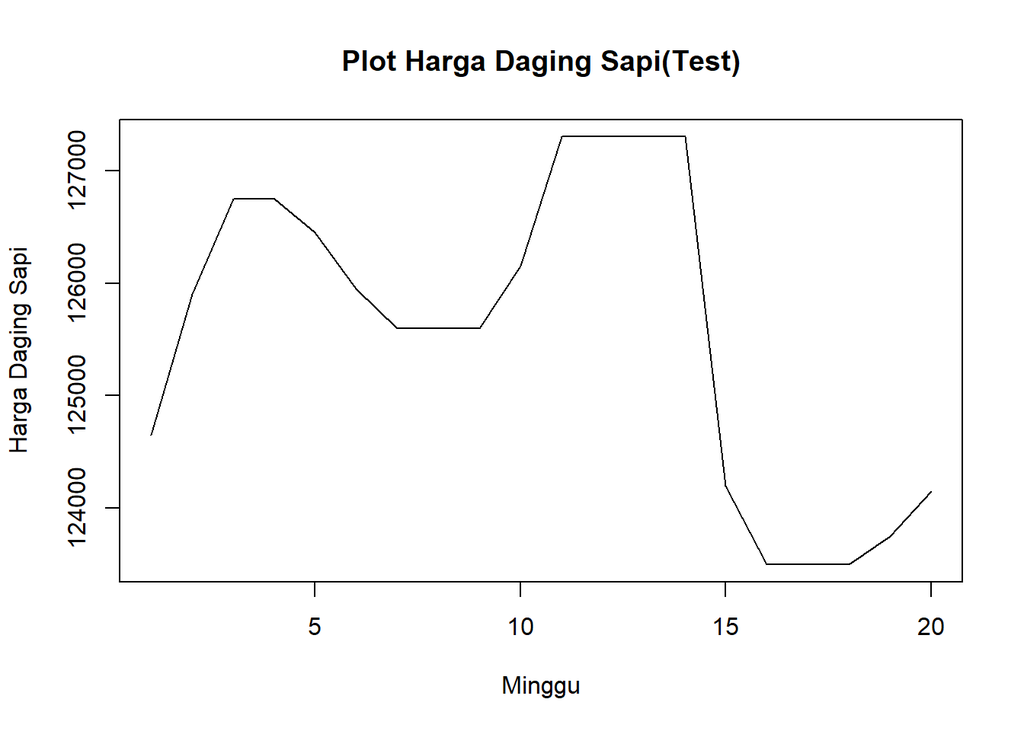

```r
datam6.test<-datam6.ts[(c+1):length(datam6.ts)]
test.ts<-ts(datam6.test)
plot.ts(test.ts, lty=1, xlab="Minggu", ylab="Harga Daging Sapi", main="Plot Harga Daging Sapi(Test)")
```

## Uji Stasioneritas Data

### Plot ACF

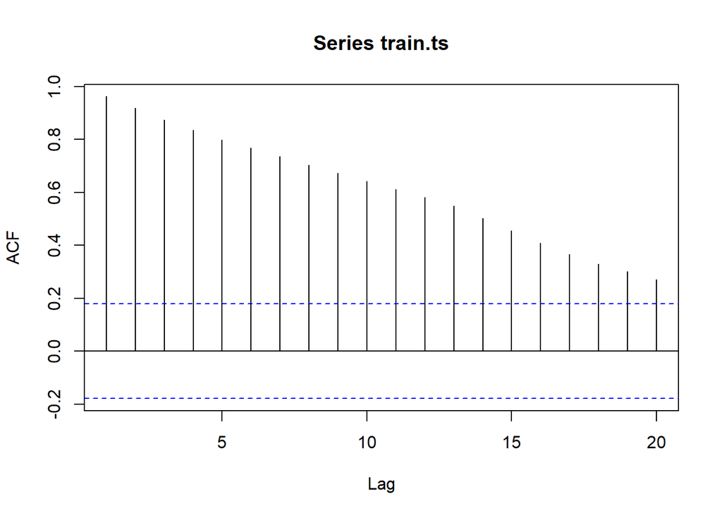

```r
acf(train.ts)
```

Berdasarkan plot ACF, terlihat bahwa plot ACF data menurun secara perlahan (*tails of slowly*). Hal ini juga menjadi indikasi bahwa data tidak stasioner dalam rataan

### Uji ADF

```r
tseries::adf.test(train.ts)
```

```
##
##  Augmented Dickey-Fuller Test
##
## data:  train.ts
## Dickey-Fuller = -2.3059, Lag order = 4, p-value = 0.4495
## alternative hypothesis: stationary
```

$H_0$ : Data tidak stasioner dalam rataan

$H_1$ : Data stasioner dalam rataan

Berdasarkan uji ADF tersebut, didapat *p-value* sebesar 0.4495 yang lebih besar dari taraf nyata 5% sehingga tak tolak $H_0$ dan menandakan bahwa data tidak stasioner dalam rataan. Hal ini sesuai dengan hasil eksplorasi menggunakan plot time series dan plot ACF, sehingga ketidakstasioneran model kedepannya harus ditangani.

### Plot Box-Cox

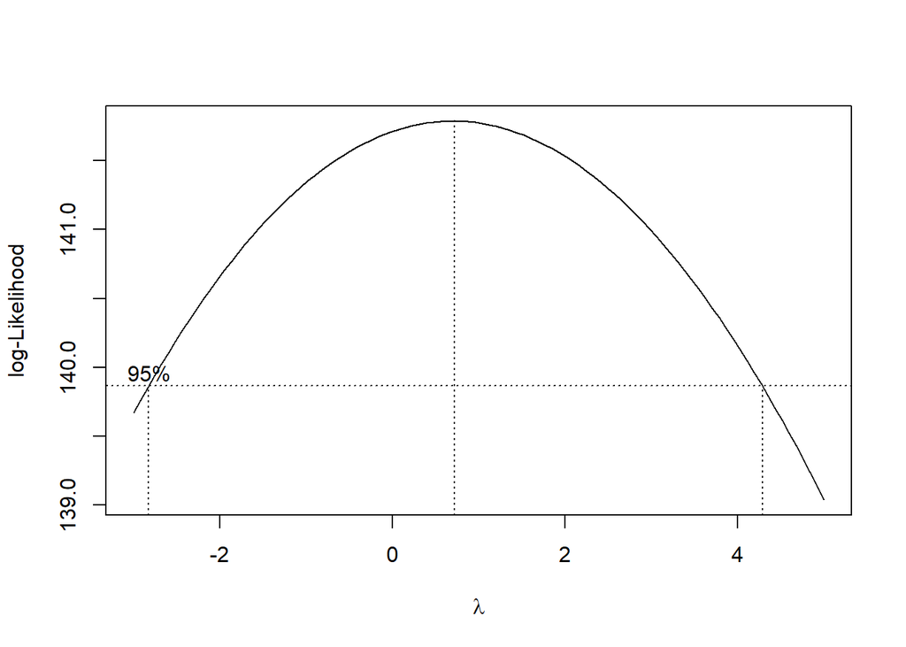

```r
index <- seq(1:c)
bc = boxcox(train.ts~index, lambda = seq(-3,5,by=0.1))
```

```r
#Nilai Rounded Lambda
lambda <- bc$x[which.max(bc$y)]
lambda
```

```
## [1] 0.7171717
```

```r
#SK
bc$x[bc$y > max(bc$y) - 1/2 * qchisq(.95,1)]
```

```
##  [1] -2.75757576 -2.67676768 -2.59595960 -2.51515152 -2.43434343 -2.35353535
##  [7] -2.27272727 -2.19191919 -2.11111111 -2.03030303 -1.94949495 -1.86868687
## [13] -1.78787879 -1.70707071 -1.62626263 -1.54545455 -1.46464646 -1.38383838
## [19] -1.30303030 -1.22222222 -1.14141414 -1.06060606 -0.97979798 -0.89898990
## [25] -0.81818182 -0.73737374 -0.65656566 -0.57575758 -0.49494949 -0.41414141
## [31] -0.33333333 -0.25252525 -0.17171717 -0.09090909 -0.01010101  0.07070707
## [37]  0.15151515  0.23232323  0.31313131  0.39393939  0.47474747  0.55555556
## [43]  0.63636364  0.71717172  0.79797980  0.87878788  0.95959596  1.04040404
## [49]  1.12121212  1.20202020  1.28282828  1.36363636  1.44444444  1.52525253
## [55]  1.60606061  1.68686869  1.76767677  1.84848485  1.92929293  2.01010101
## [61]  2.09090909  2.17171717  2.25252525  2.33333333  2.41414141  2.49494949
## [67]  2.57575758  2.65656566  2.73737374  2.81818182  2.89898990  2.97979798
## [73]  3.06060606  3.14141414  3.22222222  3.30303030  3.38383838  3.46464646
## [79]  3.54545455  3.62626263  3.70707071  3.78787879  3.86868687  3.94949495
## [85]  4.03030303  4.11111111  4.19191919  4.27272727
```

Plot Boxcox menunjukkan nilai *rounded value* ($\lambda$) optimum sebesar **0.7** dan pada selang kepercayaan 95% nilai memiliki batas bawah **-2.7** dan batas atas **4.27**. Selang tersebut memuat nilai satu sehingga dapat dikatakan bahwa data stasioner dalam ragam.

## Penanganan Ketidakstasioneran Data

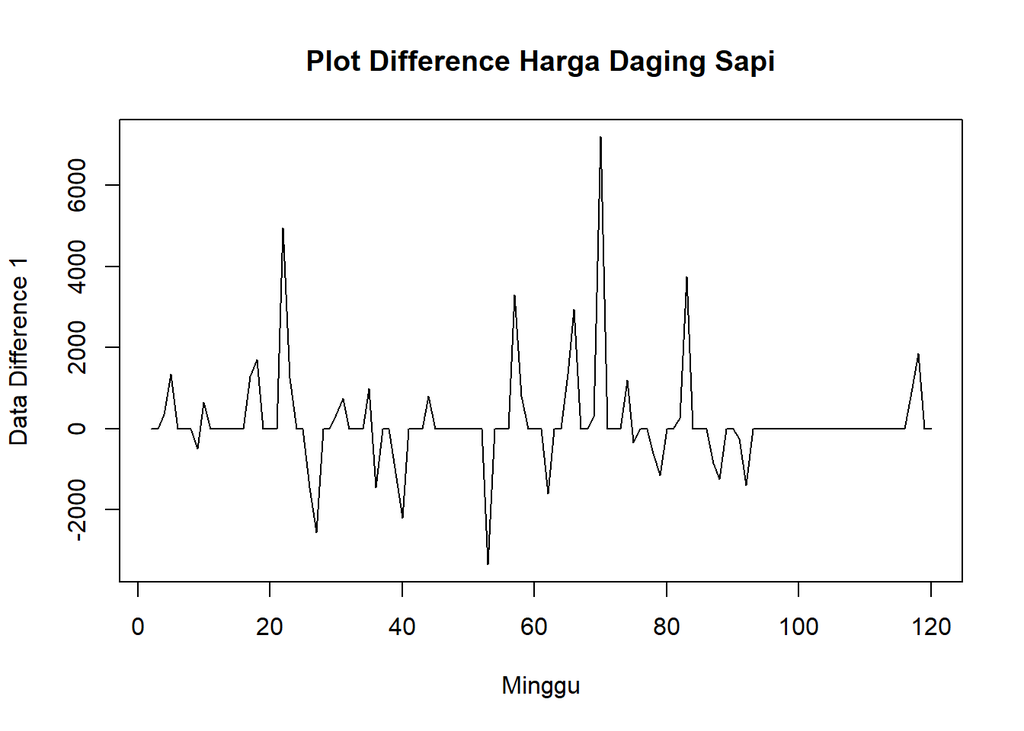

```r
train.diff<-diff(train.ts,differences = 1)
plot.ts(train.diff, lty=1, xlab="Minggu", ylab="Data Difference 1", main="Plot Difference Harga Daging Sapi")
```

Berdasarkan plot data deret waktu, terlihat bahwa data sudah stasioner dalam rataan ditandai dengan data bergerak pada nilai tengah tertentu (tidak terdapat trend ataupun musiman pada data).

### Plot ACF

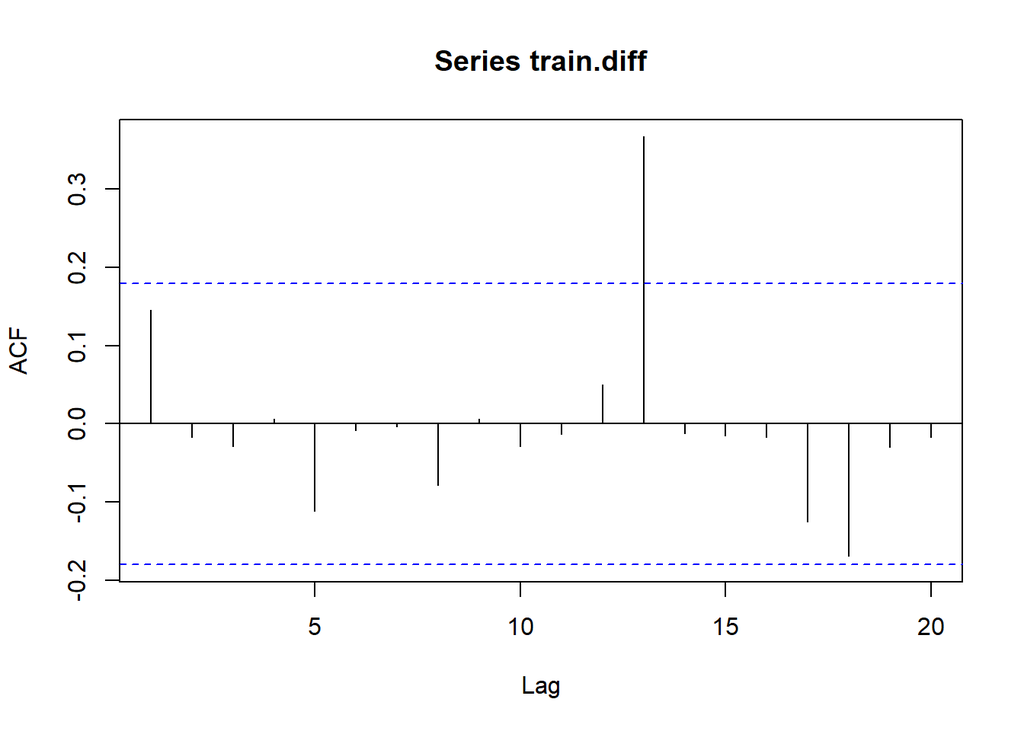

```r
acf(train.diff)
```

Berdasarkan plot tersebut, terlihat bahwa plot ACF cuts off pada lag ke 0. Hal ini menandakan data sudah stasioner dalam rataan dan ketidakstasioneran data telah berhasil tertangani.

### Uji ADF

```r
tseries::adf.test(train.diff)
```

```
##
##  Augmented Dickey-Fuller Test
##
## data:  train.diff
## Dickey-Fuller = -5.1297, Lag order = 4, p-value = 0.01
## alternative hypothesis: stationary
```

$H_0$ : Data tidak stasioner dalam rataan

$H_1$ : Data stasioner dalam rataan

Berdasarkan uji ADF tersebut, didapat *p-value* sebesar <0.01 yang lebih kecil dari taraf nyata 5% sehingga tolak $H_0$ atau data stasioner dalam rataan. Hal ini sesuai dengan hasil eksplorasi menggunakan plot time series dan plot ACF, sehingga dalam hal ini ketidakstasioneran data sudah berhasil ditangani dan dapat dilanjutkan ke pemodelan

## Identifikasi Model

### Plot ACF

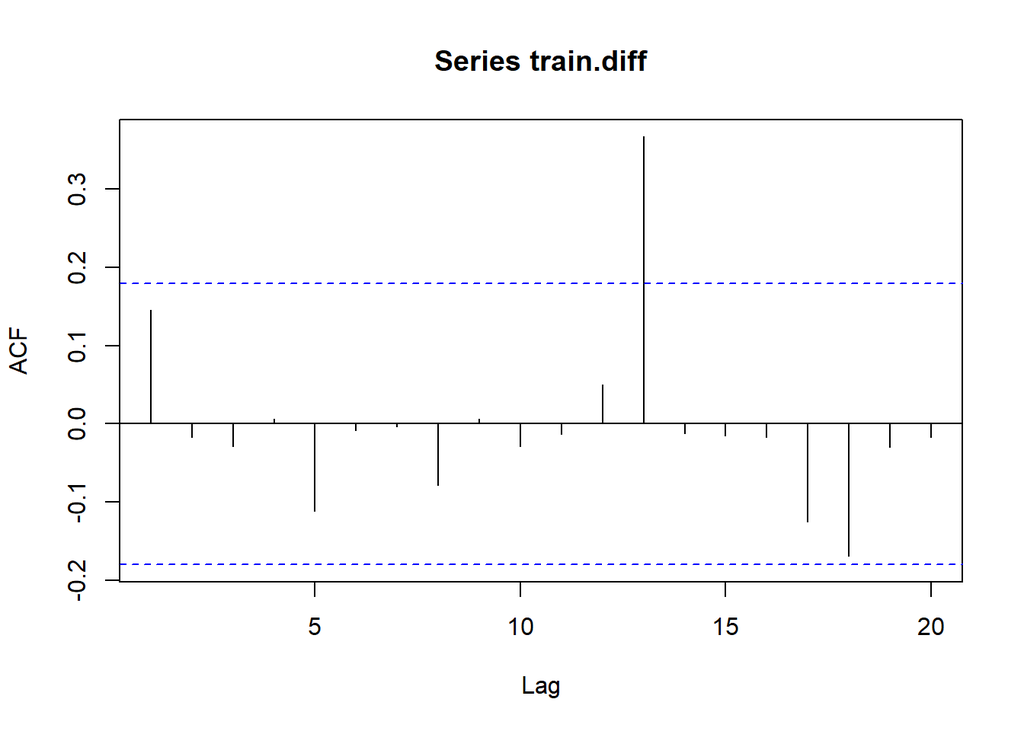

```r
acf(train.diff)
```

Berdasarkan plot tersebut, terlihat bahwa plot ACF cenderung *cuts off* sejak pada lag ke 0, sehingga tidak dapat ditentukan model dari hasil plot ACF

### Plot PACF

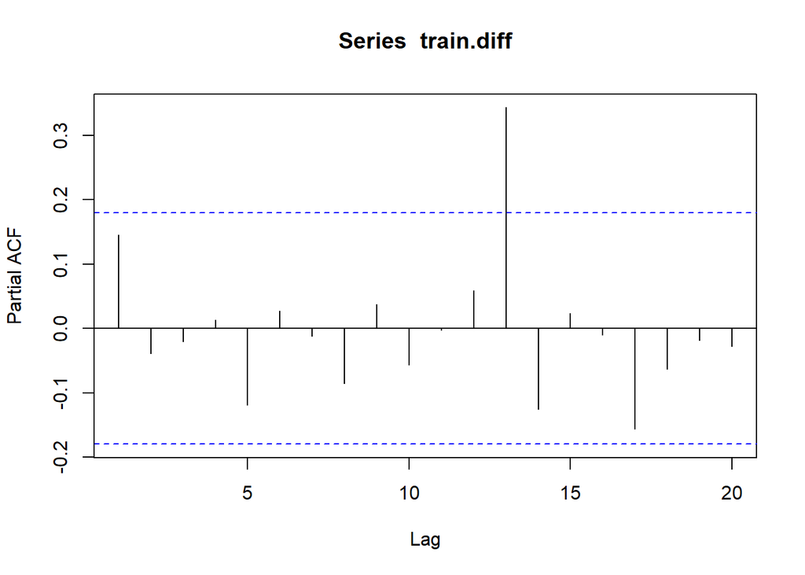

```r
pacf(train.diff)
```

Berdasarkan plot tersebut, terlihat bahwa plot PACF cenderung *cuts off* sejak pada lag ke 0, sehingga plot PACF tidak dapat digunakan untuk menentukan model tentatif.

Jika baik plot ACF maupun plot PACF keduanya dianggap tails of, maka model yang terbentuk adalah ARIMA(1,1,1)

### Plot EACF

```r
eacf(train.diff)
```

```
## AR/MA
##   0 1 2 3 4 5 6 7 8 9 10 11 12 13
## 0 o o o o o o o o o o o  o  x  o
## 1 x o o o o o o o o o o  o  x  x
## 2 x x o o o o o o o o o  o  x  x
## 3 x o o o o o o o o o o  o  x  o
## 4 o o x x o o o o o o o  o  x  o
## 5 x o x o x o o o o o o  o  x  o
## 6 x o x o o o o o o o o  o  x  o
## 7 o x x o x o o o o o o  o  x  o
```

Identifikasi model menggunakan plot EACF dilakukan dengan melihat ujung segitiga pada pola segitiga nol. Dalam hal ini model tentatif yang terbentuk adalah ARIMA(0,1,1), ARIMA(0,1,2), ARIMA(0,1,3), ARIMA(1,1,1), ARIMA(1,1,2), ARIMA(2,1,3), dan ARIMA(3,1,1).